# Introdução a modelos lineares mistos para os estudos da linguagem (aula 4)

Mahayana C. Godoy (PPgEL/UFRN)

16/11/2019

> **Para citar este material:**

> Godoy, M. C. (2019). Introdução aos modelos lineares mistos para os estudos da linguagem. PsyArXiv. https://doi.org/10.17605/OSF.IO/9T8UR

## 4. Modelos lineares mistos: contrastes e testes post-hoc

Nesta seção, vamos aprender a ajustar os contrastes de efeitos fixos para construir modelos mistos com interação entre fatores. Os tópicos de que trataremos serão:

1. A diferença entre efeito simples e efeito principal
2. Contrastes do tipo *dummy* e *sum* para os efeitos fixos
3. Análises *post-hoc*

Antes de começar, baixe e carregue os pacotes necessários.

```r
## instalar pacote

install.packages("emmeans")

## Carregar pacotes para a seção

library(lme4)
library(lmerTest)
library(ggplot2)
library(dplyr)

## pacote emmeans será carregado posteriormente
```

## 4.1 Tabela de coeficientes em MLMs com interação

O conjunto de dados `priming2.csv` traz dados de uma simulação gerada para um experimento semelhante ao apresentado na Seção 3: um pesquisador fictício quis testar o efeito de *priming* no reconhecimento de palavras-alvo apresentadas após uma palavra prime com a qual havia ou não uma relação semântica. Além disso, o experimentador também controlou o SOA de apresentação, mas dessa vez o formato curto tinha um SOA de 250ms. Vamos importar e ver esses dados.

```r
#importar conjunto de dados

priming2 <- read.csv("dados/priming2.csv")

#inspecionar dados

head(priming2)
```

```
#>      item participante       prime   SOA    tempo  resposta
#> 1 item_01         S_01 relacionado curto 961.1079   correct
#> 2 item_02         S_01 relacionado curto 687.9993   correct
#> 3 item_03         S_01 relacionado curto 819.4017 incorrect
#> 4 item_04         S_01 relacionado curto 786.8615   correct
#> 5 item_05         S_01 relacionado curto 943.5287   correct
#> 6 item_06         S_01 relacionado curto 682.6980 incorrect
```

```r
#conhecer variáveis

str(priming2)
```

```
#> 'data.frame':    1200 obs. of  6 variables:
#>  $ item        : Factor w/ 60 levels "item_01","item_02",..: 1 2 3 4 5 6 7 8 9 10 ...
#>  $ participante: Factor w/ 20 levels "S_01","S_02",..: 1 1 1 1 1 1 1 1 1 1 ...
#>  $ prime       : Factor w/ 2 levels "nrelacionado",..: 2 2 2 2 2 2 2 2 2 2 ...
#>  $ SOA         : Factor w/ 2 levels "curto","longo": 1 1 1 1 1 1 1 1 1 1 ...
#>  $ tempo       : num  961 688 819 787 944 ...
#>  $ resposta    : Factor w/ 2 levels "correct","incorrect": 1 1 2 1 1 2 1 1 1 1 ...
```

Os nomes das variáveis são os mesmos que já conhecemos. Vamos começar a análise pela inspeção e limpeza de dados.

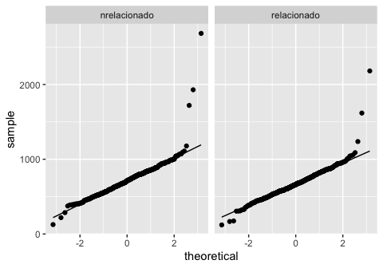

```r
## Conferindo distribuição de dados

ggplot(priming2, aes(sample = tempo))+
  stat_qq()+
  stat_qq_line()+
  facet_wrap(~prime)
```

Pelo gráfico acima, vimos que a distribuição de dados parece normal, exceto pelos valores que estão fora da nossa faixa estabelecida de 200ms a 1500ms. Como fizemos na Seção 3, excluímos os valores que consideramos *outliers*, conferimos a distribuição novamente e extraímos as médias para cada uma das condições para conhecermos melhor nosso conjunto de dados.

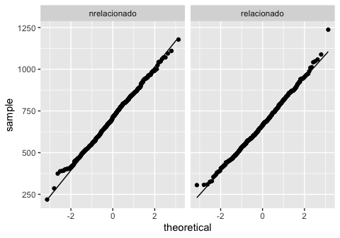

```r
## Selecionando apenas resposta cujo tempo esteja entre 200 ms e 1500 ms e que estejam marcadas como correct para a variável resposta

priming2 = priming2%>%
  filter(tempo > 200 & tempo < 1500 & resposta == "correct")

## Conferindo novamente a distribuição dos dados

ggplot(priming2, aes(sample = tempo))+
  stat_qq()+
  stat_qq_line()+
  facet_wrap(~prime)
```

```r
## Vendo a média (em ms) dos tempos de reação para as quatro condições

priming2%>%
  group_by(prime, SOA)%>%
  summarise(mean(tempo))
```

```
#> # A tibble: 4 x 3
#> # Groups:   prime [2]
#>   prime        SOA   `mean(tempo)`
#>   <fct>        <fct>         <dbl>
#> 1 nrelacionado curto          706.
#> 2 nrelacionado longo          710.
#> 3 relacionado  curto          694.
#> 4 relacionado  longo          643.
```

Se quisermos (e é recomendável), podemos ver a distribuição por participante para identificar se há algum se comportando de forma anômala.

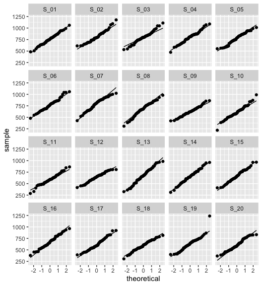

```r
## Conferindo distribuição de dados por participante

ggplot(priming2, aes(sample = tempo))+
  stat_qq()+
  stat_qq_line()+
  facet_wrap(~participante)
```

Podemos agora construir nosso modelo linear misto para investigar se prime e SOA influenciam o tempo de resposta. Como aprendemos, primeiro tentamos criar o modelo com a arquitetura máxima de efeitos aleatórios, retirando *slopes* para resolver problemas de convergência.

```r
# construção do modelo completo (erro de convergência)

model.full <- lmer(tempo ~ prime*SOA + (1+prime*SOA|participante) + (1+prime*SOA|item), data = priming2, REML=FALSE)

# remoção de slopes para participante (erro de convergência)

model.full <- lmer(tempo ~ prime*SOA + (1|participante) + (1+prime*SOA|item), data = priming2, REML=FALSE)

# remoção de slopes para item

model.full <- lmer(tempo ~ prime*SOA + (1|participante) + (1|item), data = priming2, REML=FALSE)
```

Conseguimos alcançar convergência com o terceiro modelo, que tem prime, SOA e a interação entre essas condições como efeitos fixos, além de interceptos aleatórios para participante e item. Comparamos esse modelo com o modelo aninhado `model.prime.SOA`. O resultado da comparação indica que a interação tem efeito significativo.

```r
# modelo sem interação

model.prime.SOA <- lmer(tempo ~ prime+SOA + (1|participante) + (1|item), data = priming2, REML=FALSE)

# comparação de modelos aninhados

anova(model.full, model.prime.SOA)
```

```
#> Data: priming2
#> Models:
#> model.prime.SOA: tempo ~ prime + SOA + (1 | participante) + (1 | item)
#> model.full: tempo ~ prime * SOA + (1 | participante) + (1 | item)
#>                 Df   AIC   BIC  logLik deviance  Chisq Chi Df Pr(>Chisq)
#> model.prime.SOA  6 14619 14649 -7303.3    14607
#> model.full       7 14604 14640 -7295.2    14590 16.189      1  5.734e-05
#>
#> model.prime.SOA
#> model.full      ***
#> ---
#> Signif. codes:  0 '***' 0.001 '**' 0.01 '*' 0.05 '.' 0.1 ' ' 1
```

```r
## Resultado: interação é significativo
```

Vamos dar uma olhada na tabela de coeficientes do modelo e compará-la com as médias de tempos de resposta por prime e por SOA, além de retomarmos as médias para cada uma das condições.

```r
# média por prime

priming2%>%
  group_by(prime)%>%
  summarise(media = mean(tempo))
```

```
#> # A tibble: 2 x 2
#>   prime        media
#>   <fct>        <dbl>
#> 1 nrelacionado  708.
#> 2 relacionado   668.
```

```r
# média por SOA

priming2%>%
  group_by(SOA)%>%
  summarise(media = mean(tempo))
```

```
#> # A tibble: 2 x 2
#>   SOA   media
#>   <fct> <dbl>
#> 1 curto  700.
#> 2 longo  677.
```

```r
# média por prime x SOA

priming2%>%
  group_by(SOA, prime)%>%
  summarise(media = mean(tempo))%>%
  mutate_if(is.numeric, format, 1) ## retorna valores com 4 dígitos depois do ponto
```

```
#> # A tibble: 4 x 3
#> # Groups:   SOA [2]
#>   SOA   prime        media
#>   <fct> <fct>        <chr>
#> 1 curto nrelacionado 706.2971
#> 2 curto relacionado  693.9389
#> 3 longo nrelacionado 710.2517
#> 4 longo relacionado  643.2373
```

```r
# coeficientes do modelo

summary(model.full)
```

```
#> Linear mixed model fit by maximum likelihood . t-tests use
#>   Satterthwaite's method [lmerModLmerTest]
#> Formula: tempo ~ prime * SOA + (1 | participante) + (1 | item)
#>    Data: priming2
#>
#>      AIC      BIC   logLik deviance df.resid
#>  14604.4  14639.9  -7295.2  14590.4     1159
#>
#> Scaled residuals:
#>     Min      1Q  Median      3Q     Max
#> -3.3611 -0.6517  0.0017  0.6681  5.1576
#>
#> Random effects:
#>  Groups       Name        Variance Std.Dev.
#>  item         (Intercept)   199     14.11
#>  participante (Intercept)  5592     74.78
#>  Residual                 14913    122.12
#> Number of obs: 1166, groups:  item, 60; participante, 20
#>
#> Fixed effects:
#>                           Estimate Std. Error       df t value Pr(>|t|)
#> (Intercept)                705.983     18.258   25.958  38.668  < 2e-16
#> primerelacionado           -11.465     10.102 1089.326  -1.135    0.257
#> SOAlongo                     5.699     10.102 1089.020   0.564    0.573
#> primerelacionado:SOAlongo  -57.804     14.311 1089.750  -4.039 5.74e-05
#>
#> (Intercept)               ***
#> primerelacionado
#> SOAlongo
#> primerelacionado:SOAlongo ***
#> ---
#> Signif. codes:  0 '***' 0.001 '**' 0.01 '*' 0.05 '.' 0.1 ' ' 1
#>
#> Correlation of Fixed Effects:
#>             (Intr) prmrlc SOAlng
#> primerelcnd -0.273
#> SOAlongo    -0.273  0.494
#> prmrlcn:SOA  0.193 -0.706 -0.706
```

Para tentar entender os coeficientes, vamos olhar o intercepto do modelo. Nosso primeiro instinto seria achar que o intercepto corresponde à condição de prime não-relacionado. Contudo, o tempo de resposta médio para a condição de prime não-relacionado foi de 708ms. Se olharmos com atenção, veremos que o valor do intercepto diz respeito ao tempo médio da condição não-relacionado *quando o SOA é curto*.

Há uma pequena discrepância entre os valores da tabela gerada a partir de `summarise()` e os valores dos coeficientes que vemos aqui (706ms vs 705.98ms), mas isso se deve ao fato de os valores da tabela de coeficientes levarem em conta os efeitos aleatórios de participante e item. Outras pequenas discrepâncias aparecerão mais adiante.

Vamos preencher a **Tabela 4.1** com os valores médios de tempo de resposta que conseguimos descobrir através da tabela de coeficientes.

|  | nrelacionado | relacionado |
| --- | --- | --- |
| curto | 705.9ms |  |
| longo |  |  |

**Tabela 4.1:** Valor do intercepto entre as quatro condições experimentais

Voltando aos coeficientes, vimos que o valor de $\beta$ para a linha `primerelacionado` é -11.465. Somando esse valor ao intercepto, chegamos ao valor do 694.51, que é próximo à média de tempo de resposta para a condição `relacionado+curto`. O que o p-valor dessa linha indica, então, é que a diferença entre as condições relacionado e não-relaciodo *quando o SOA é curto* não é significativa (p = 0.257). Preenchemos esse valor na a **Tabela 4.2** e destacamos os valores que a linha `primerelacionado` está comparando.

|  | nrelacionado | relacionado |
| --- | --- | --- |
| curto | **705.9ms** | **694.5ms** |
| longo |  |  |

**Tabela 4.2:** Comparação de valores do intercepto e da condição curto-relacionado

A próxima linha, `SOAlongo`, indica um $\beta$ de 5.699. Somado ao intercepto, temos 711.5ms, um valor próximo ao valor médio do tempo de reação da condição `nrelacionado+longo`. Vemos, portanto, que não há diferença significativa entre as condições de SOA *quando o prime é não-relacionado* (p = 0.573). Preenchemos esse valor na **Tabela 4.3** e destacamos a comparação feita pela linha `SOAlongo`.

|  | nrelacionado | relacionado |
| --- | --- | --- |
| curto | **705.9ms** | 694.5ms |
| longo | **711.5ms** |  |

**Tabela 4.3:** Comparação de valores do intercepto e da condição longo-nrelacionado

[output not shown]

**Tabela 4.4:** Comparação de valores do intercepto e da condição longo-relacionado

Como vimos, a tabela de coeficientes do modelo nos dá uma série de comparações. Cabe, agora, nos perguntarmos se elas são informativas. Vimos que o efeito de prime não é significativo quando o SOA é curto, mas será que é quando quando o SOA é longo? Ou, desconsiderando SOA, será que teríamos um efeito de prime? O efeito de SOA não foi significativo para a condição de prime não-relacionado, mas será que esse resultado se mantem quando para primes relacionados? Por fim, de que vale comparar o tempo de reação da condição prime não-relacionado de SOA curto com a condição de prime relacionado com SOA longo? Essa comparação se dá em níveis diferentes de cada uma das condições, e portanto não é informativa nem sobre os efeitos de prime, nem de SOA e nem da interação entre essas variáveis.

## 4.2 Efeito simples e efeito principal

Para entender a tabela de coeficientes que a função `lmer` constrói por *default*, precisamos primeiro entender a diferença entre efeito principal e efeito simples. Considere a **Tabela 4.5**, que traz novamente a média de tempo de reação por condição e suas médias marginais. Para facilitar nossa explicação e conseguirmos generalizar para outras situações, estamos chamando a condição prime de A e a condição SOA de B.

A média marginal $\mu_{B1}$ de 700ms, por exemplo, indica o valor médio de tempo de resposta da condição $B_1$ ignorando os níveis da condição A (no caso de nosso experimento, a média dos itens de SOA curto, independente do tipo de prime). Testar o **efeito principal** de B é testar a hipótese nula de que $\mu_{B1}$ = $\mu_{B2}$. Por outro lado, testar um **efeito simples** de B é testar o efeito de B *para um nível específico de A* - por exemplo, seria testar hipótese nula de que $\mu_{A1.B1}$ = $\mu_{A1.B2}$.

|  | nrelacionado $(A_1)$ | relacionado $(A_2)$ |  |  |  |
| --- | --- | --- | --- | --- | --- |
| curto ($B_1$) | $\mu_{A1.B1}$ = 705.9ms | $\mu_{A2.B1}$ = 694.5ms |  |  | $\mu_{B1}$ = 700ms |
| longo ($B_2$) | $\mu_{A1.B2}$ = 711.5ms | $\mu_{A2.B2}$ = 648.0ms |  |  | $\mu_{B2}$ = 679ms |
|  | $\mu_{A1}$ = 708.7ms | $\mu_{A2}$ = 671.2ms |  |  |  |

**Tabela 4.5**: médias e médias marginais de um experimento 2x2

Em seu post sobre contrastes e efeitos simples/principais[^1], Dale Barr resume a questão da seguinte maneira:

> Em um desenho AxB, o efeito simples de A é o efeito de A **controlando** B, equanto o efeito principal de A é o efeito de A **ignorando** B.

Muitas vezes (pelo menos em experimentos na área da psicologia) estamos interessados em efeitos principais e sua interação. Testes como a ANOVA, por exemplo, já reportam os efeitos principais em seus resultados. Se é esse o nosso interesse, a tabela de coeficientes de um modelo linear é pouco útil ou informativa, pois mostra apenas efeitos simples. Isso acontece porque o intercepto do modelo é construído a partir de um tipo específico de contraste entre condições, definido por *default* nas funções de modelos lineares. Se quisermos que a tabela de coeficientes informe efeitos e interações principais, precisamos mudar explicitamente esse tipo de contraste.

## 4.3 Contrastes

Quando estudamos a construção de um modelo linear na Seção 2, fizemos uma representação gráfica para mostrar que o modelo assume o nível de referência de uma variável como tendo valor igual a 0, e o nível subsequente com valor igual a 1. Vimos também que, ao assumir valor igual a 0, esse nível de referência assume o valor de intercepto. Esse tipo de **contraste** entre as variáveis pode ser chamada de *dummy coding* ou *treatment*, e é a codificação *default* dos modelos lineares. Podemos ver essa codificação pedindo para a função `contrasts()` nos mostrar o contraste entre as variáveis de `SOA` e `prime`.

```r
# conferindo sum coding para variável priming

contrasts(priming2$prime)
```

```
#>              relacionado
#> nrelacionado           0
#> relacionado            1
```

```r
# conferindo sum coding para variável SOA

contrasts(priming2$SOA)
```

```
#>       longo
#> curto     0
#> longo     1
```

Para uma variável `A` com os níveis $A_1$ e $A_2$, o *dummy coding* pode ser descrito pela Tabela 4.6.

|  | *dummy coding* |
| --- | --- |
| $A_1$ | 0 |
| $A_2$ | 1 |

**Tabela 4.6:** Dummy coding para condição com dois níveis

Recuperando aqui o que foi discutido na Seção 2 para modelos lineares com efeitos fixos categóricos, como gênero, podemos ver que o valor desse contraste é útil porque entra no cálculo do modelo linear. Na ocasião, vimos que 226.33 era o valor de $\beta_0$ (valor do coeficiente quando y é zero, que no caso correspondia ao gênero feminino). O valor $x_1$ tinha o valor de 1 porque vimos que o nível `masculino` foi assim codificado pelo modelo, e com esses valores conseguimos calcular a média do nível masculino.

> **Relembrando cálculo de y na regressão com uma variável**

> $y=\beta_{0}+\beta_{1}x_{1}$

> Se quisermos calcular o valor de `y` para masculino (o nosso $x_1$), podemos substituir essa equação pelo valores obtidos em nosso modelo linear:

> $\beta_{0}$ = 226.33

> $\beta_{1}$ = -98.33

> $x_1$ = 1

> y = 226.33 + (-98.33*1) = 128

A tabela de coeficientes de um modelo linear com contrastes do tipo *dummy* mostra resultados referentes aos efeitos simples das variáveis envolvidas. Quando nosso experimento tem apenas uma variável de 2 níveis, isso não é um problema: afinal, o objetivo último da análise será contrastar $A_1$ e $A_2$. Contudo, como vimos com os resultados de `model.full`, isso pode ser um problema quando queremos reportar efeitos principais envolvendo mais de uma variável e suas interações.

Em um experimento 2x2, podemos usar o chamado *sum coding* (cf. **Tabela 4.7**) para opor dois níveis de uma variável. Dessa maneira, os resultados da tabela de coeficientes mostrarão efeitos principais para as variáveis testadas. Ao mudarmos o contraste para aplicar o *sum coding* a uma variável, opomos seus níveis usando os valores positivos e negativos, frequentemente 0.5 e -0.5, o que mudará o cálculo de $\beta_0$. Nessa situação o $\beta_0$ deixará de corresponder a um dos níveis da variável e passará a corresponder ao valor médio geral das observações).

|  | *sum coding* |
| --- | --- |
| $A_1$ | -0.5 |
| $A_2$ | 0.5 |

**Tabela 4.7:** sum coding para condição com dois níveis

Para entendermos como isso é feito, vamos re-codificar nossas variáveis `prime` e `SOA`, rodar o modelo linear novamente e analisar os resultados.

```r
# ajustando e conferindo sum coding para variável priming

contrasts(priming2$prime) = c(-0.5, 0.5)
contrasts(priming2$prime)
```

```
#>              [,1]
#> nrelacionado -0.5
#> relacionado   0.5
```

```r
# ajustando e conferindo sum coding para variável SOA

contrasts(priming2$SOA) = c(-0.5,0.5)
contrasts(priming2$SOA)
```

```
#>       [,1]
#> curto -0.5
#> longo  0.5
```

```r
# ajustando novamente o modelo linear com os novos contrastes

model.full <- lmer(tempo ~ prime*SOA + (1|participante) + (1|item), data = priming2, REML=FALSE)

## resultado

summary(model.full)
```

```
#> Linear mixed model fit by maximum likelihood . t-tests use
#>   Satterthwaite's method [lmerModLmerTest]
#> Formula: tempo ~ prime * SOA + (1 | participante) + (1 | item)
#>    Data: priming2
#>
#>      AIC      BIC   logLik deviance df.resid
#>  14604.4  14639.9  -7295.2  14590.4     1159
#>
#> Scaled residuals:
#>     Min      1Q  Median      3Q     Max
#> -3.3611 -0.6517  0.0017  0.6681  5.1576
#>
#> Random effects:
#>  Groups       Name        Variance Std.Dev.
#>  item         (Intercept)   199     14.11
#>  participante (Intercept)  5592     74.78
#>  Residual                 14913    122.12
#> Number of obs: 1166, groups:  item, 60; participante, 20
#>
#> Fixed effects:
#>             Estimate Std. Error       df t value Pr(>|t|)
#> (Intercept)  688.649     17.197   20.433  40.045  < 2e-16 ***
#> prime1       -40.367      7.156 1089.950  -5.641 2.16e-08 ***
#> SOA1         -23.203      7.156 1089.947  -3.242  0.00122 **
#> prime1:SOA1  -57.804     14.311 1089.750  -4.039 5.74e-05 ***
#> ---
#> Signif. codes:  0 '***' 0.001 '**' 0.01 '*' 0.05 '.' 0.1 ' ' 1
#>
#> Correlation of Fixed Effects:
#>             (Intr) prime1 SOA1
#> prime1       0.001
#> SOA1         0.001 -0.009
#> prime1:SOA1 -0.002  0.003  0.003
```

Os valores da tabela de coeficiente agora são mais informativos. O intercepto agora corresponde ao tempo médio de resposta ignorando as condições experimentais (de novo há pequenas diferenças causadas pelo fato de o modelo considerar efeitos aleatórios de participantes e itens).

```r
## média de tempo de resposta

mean(priming2$tempo)
```

```
#> [1] 688.4222
```

A linha `prime1` agora mostra o contraste que definimos entre os níveis das condições prime, e não a comparação direta com o intercepto. Vemos que o $\beta$ dessa linha é -40.367, próximo à diferença entre as condições de prime *ignorando o efeito de SOA*:

```r
# média por prime

priming2%>%
  group_by(prime)%>%
  summarise(media = mean(tempo))
```

```
#> # A tibble: 2 x 2
#>   prime        media
#>   <fct>        <dbl>
#> 1 nrelacionado  708.
#> 2 relacionado   668.
```

```r
# beta de prime1

708 - 668
```

```
#> [1] 40
```

Similarmente, vemos que o $\beta$ de `SOA1` é -23.203. Essa é a diferença entre as condições de SOA *ignorando o efeito de prime*.

```r
# media por SOA

priming2%>%
  group_by(SOA)%>%
  summarise(media = mean(tempo))
```

```
#> # A tibble: 2 x 2
#>   SOA   media
#>   <fct> <dbl>
#> 1 curto  700.
#> 2 longo  677.
```

```r
# beta de SOA1

700 - 677
```

```
#> [1] 23
```

Ou seja, a tabela de coeficientes agora informa os efeitos principais de prime e SOA, obtido através das médias marginais que indicamos na **Tabela 4.5**. Como a análise por modelos aninhados nos mostrou que houve interação significativa, convém ter cautela ao reportar esses efeitos principais, mas faremos isso ao criar análises post-hoc na seção seguinte. Por enquanto, vamos analisar a linha `prime1:SOA1`.

Dessa vez, essa linha está mostrando a diferença entre os níveis de prime para SOA curto e os níveis de prime para SOA longo. Confuso? Vamos fazer o cálculo na mão e veremos que temos um valor similar o $\beta$ da interação, que foi de -57.8.

```r
# média por prime x SOA

priming2%>%
  group_by(SOA, prime)%>%
  summarise(media = mean(tempo))%>%
  mutate_if(is.numeric, format, 1)
```

```
#> # A tibble: 4 x 3
#> # Groups:   SOA [2]
#>   SOA   prime        media
#>   <fct> <fct>        <chr>
#> 1 curto nrelacionado 706.2971
#> 2 curto relacionado  693.9389
#> 3 longo nrelacionado 710.2517
#> 4 longo relacionado  643.2373
```

```r
## calculando diferenças

# SOAcurto nrelacionado - SOAcurto relacionado

efeito.curto = 706.2971 - 693.9389

# SOAlongo nrelacionado - SOAlongo relacionado

efeito.longo = 710.2517 - 643.2373

# Diferença entre os valores

efeito.curto - efeito.longo
```

```
#> [1] -54.6562
```

Existem outras maneiras de codificar contrastes e elas vão depender (a) da natureza de seus dados; (b) de que tipo de informação você quer extrair deles; (c) do número de níveis que você tem para uma variável. Aqui vamos apenas tratar de casos de experimentos 2x2 para situações em que queremos extrair informação sobre efeitos principais. Se esse não for o seu caso, não se esqueça de estudar qual a melhor maneira de codificar suas variáveis[^2].

### Tarefa: contrastes e modelos

Antes de continuarmos, vamos fazer uma pausa e ver se você agora consegue entender um pouco melhor a descrição da seção de análise de alguns artigos. Leia o trecho abaixo e responda:

- Que tipo de contraste os autores usaram para os efeitos fixos?
- Como seria a equação do modelo ajustado?

> **Modelo 1**

> *“The response variable was the rate of the coherence relations; aspect was the only fixed effect, and it was contrasted using treatment coding to allow for a direct comparison between perfective and imperfective contexts. The model included random intercepts for participants and items, and random slopes for aspect.”* (Godoy et al. 2018)

> **Modelo 2**

> *“The results were statistically analyzed using generalized (binomial) mixed-effects models with crossed random effects for subjects and items (Baayen et al., 2008). The predictors PROSODIC STRESS (noun stress vs. quantifier stress) and CONTEXT (alternative type present vs. alternative type absent) were sum-coded (as 0.5 and -0.5) and used as fixed predictors, along with their interaction; random effects of these three parameters were also fit for items (Barr et al., 2013), but not for subjects, since each subject had too few trials to fit this complex structure well.”* (Chen et al. 2018)

## 4.4 Análises *post-hoc*

A tabela de coeficientes nos informa que há efeito de prime, SOA e interação. Contudo, não sabemos que efeitos são esses. Como SOA afetou prime? Será que o efeito de prime só se fez sentir nas condições de SOA longo? Ou será que se fez presente nas duas condições, mas com um efeito muito maior nas condições de SOA longo?

Essas são perguntas que só posso me fazer *depois* de realizar a análise inicial dos dados. Como os testes que preciso fazer para responder a essas perguntas são pensados apenas depois dessa análise inicial que já fizemos, chamamo-os de **testes *post-hoc***.

No caso de nosso experimento, uma análise *post-hoc* deverá comparar par-a-par as condições experimentais para identificar onde e como houve o efeito de interação entre *prime* e SOA. O pacote para análises *post-hoc* de modelos lineares se chama `emmeans`. Vamos começar baixando e carregado o pacote

```r
# carregar emmeans

library(emmeans)
```

Vamos fazer a análise com a função `emmeans()` e salvar o resultado em um objeto de nome `post.hoc`. Ao fazermos essa análise, especificamos o modelo a partir do qual a análise é feita (`model.full`) e indicamos que queremos as comparações considerando os níveis de *prime*, *SOA* e sua interação (`~ prime*SOA`). Depois, usamos a função `pairs` para extrair a comparação por pares de `post.hoc`.

```r
# análise post-hoc

post.hoc = emmeans(model.full, ~ prime*SOA)

# visualização dos pares da análise post-hoc

pairs(post.hoc, adjust="tukey")
```

```
#>  contrast                                estimate   SE   df t.ratio
#>  nrelacionado,curto - relacionado,curto      11.5 10.1 1092  1.133
#>  nrelacionado,curto - nrelacionado,longo     -5.7 10.1 1092 -0.563
#>  nrelacionado,curto - relacionado,longo      63.6 10.1 1092  6.301
#>  relacionado,curto - nrelacionado,longo     -17.2 10.2 1094 -1.686
#>  relacionado,curto - relacionado,longo       52.1 10.2 1094  5.133
#>  nrelacionado,longo - relacionado,longo      69.3 10.2 1093  6.823
#>  p.value
#>  0.6690
#>  0.9429
#>  <.0001
#>  0.3315
#>  <.0001
#>  <.0001
#>
#> P value adjustment: tukey method for comparing a family of 4 estimates
```

O resultado mostra seis comparações resultantes de análises par-a-par, bem como os p-valores associados. Você deve ter percebido que especificamos `adjust = "tukey"` na sintaxe para extração das comparações pareadas. O que esse ajuste faz é corrigir o p-valor dessas comparações.

Imagine que você tem um saco com 20 bolinhas: 19 pretas e uma vermelha. Qual a probabilidade de tirar uma bolinha vermelha ao pegar uma bolinha qualquer desse saco? A probabilidade é de 1/20, ou 0.05. Agora imagine que você repetiu essa operação 10 vezes. Quanto mais você repete essa operação, maior a chance de você pegar essa bolinha vermelha *ao menos uma vez*. A lógica da **correção do p-valor** é mais ou menos essa. Há uma chance de um efeito significativo ser, na verdade, um **falso positivo**: ele está em nossos dados, mas se deu ao acaso e não por causa das variáveis que estamos controlando. Quanto mais testes de hipóteses fazemos, maior a chance de termos um falso positivo. Por isso, sempre que fazemos testes de múltiplas comparações, é importante corrigir o p-valor. Há outros métodos de correção, mas Tukey costuma ser o mais usado na psicologia. Como vimos, é bem simples aplicá-lo na sintaxe de `emmeans`.

## 4.5 Prática: contrastes e testes post-hoc

O conjunto de dados `proinf.cvs` traz um subconjunto dos dados de Godoy (2014).

Nesse experimento de leitura autocadenciada, a autora testou a influência do tipo de pronome - plural ou singular - e do tipo de referência - correferencial ou inferível - no tempo de leitura de expressões pronominais. Abaixo, há um exemplo de itens experimentais usados (as sentenças estão pela metade):

1. **Pronome singular em relação de co-referência:**

Ângelo trabalha como secretário e **ele** geralmente…

2. **Pronome plural em relação de co-referência:**

Ângelo e Chico trabalhavam como secretários e **eles** geralmente…

3. **Pronome singular em relação de referência inferível:**

Na escola do bairro, Rebeca trabalha como secretária e **ele** geralmente…

4. **Pronome plural em relação de referência inferível:**

Na escola do bairro, Rebeca trabalhava como secretária e **eles** geralmente…

Nas sentenças (1) e (2), os pronomes destacados são co-referentes, respectivamente, a “Ângelo” e “Ângelo e Chico”. Em (3) e (4), os mesmos pronomes não tem qualquer referente definido na sentença anterior, mas é possível inferir um referente através da expressão “Na escola do bairro”.

A hipótese de Godoy (2014) era de que pronomes singulares dão início à busca por um co-referente sempre que encontrados, enquanto pronomes plurais instanciam uma leitura indefinida na falta de um referente. Portanto os tempos de leitura do pronome na condição (1), (2) e (4) seriam iguais, enquanto o pronome em (3) geraria um tempo de leitura maior pela quebra de co-referência.

Como pronomes são palavras muito pequenas, é normal o efeito esperado ocorrer na palavra seguinte da sentença (esse efeito é chamado de *spill-over*). No experimento em questão, essa palavra era sempre um advérbio, e o seu tempo de leitura está salvo na planilha `proinf.cvs`.

O conjunto de dados têm 5 colunas:

- `cod`, com identificação dos 42 sentenças experimentais;
- `participante`, com identificação dos participantes da pesquisa;
- `pronome`, com indicação de pronome plural (`p`) ou singular (`s`);
- `referencia`, com indicação de referência co-referencial (`cor`) ou inferível (`inf`);
- `tempo.adverbio`, com o tempo de leitura do adverbio.

**Tarefa**

Para saber se a hipótese se confirmou,

- importe o conjunto de dados;
- filtre apenas as observações em que os participantes acertaram a pergunta feita sobre o item experimental;
- inspecione a distribuição dos tempos de resposta para a palavra crítica e elimine outliers e observações com tempo de resposta maior que 2000ms;
- transforme os dados se achar necessário;
- ajuste o contraste mais adequado para a análise;
- construa um modelo linear misto para analisar se tipo de pronome, tipo de referência e a interação entre esses fatores conseguem explicar a distribuição de dados;
- faça análise por modelos aninhados se necessário;
- faça análises post-hoc se necessário;
- faça análise dos resíduos.

Não se esqueça de ir anotando o seu código para mostrar o que você está fazendo e justificar suas decisões. Ao final, escreva os resultados como se fosse um artigo.

> **Importante!** As análises que vamos fazer aqui são bem diferentes daquelas apresentadas em Godoy (2014), ainda que as conclusões sejam as mesmas. No estudo original, há um terceiro nível para a variável pronome.

## REFERÊNCIAS

Chen I-H, Huang C-R and Politzer-Ahles S (2018) Determining the Types of Contrasts: The Influences of Prosody on Pragmatic Inferences. Front. Psychol. 9:2110. doi: 10.3389/fpsyg.2018.02110

Godoy, M. C.; Weissheimer, J. ; Mafra, M. A. When Grammar Meets Pragmatics: Subject Preference and Coherence Relations in Brazilian Portuguese Pronoun Interpretation. Journal of Portuguese Linguistics, v. 17, p. 17, doi: 10.5334/jpl.197.

Godoy, M. C. (2014) Processamento de pronomes plurais não anafóricos. Revista Linguí∫tica, v. 10, p. 175-192.

[^1]: Você pode ver o post completo aqui http://talklab.psy.gla.ac.uk/tvw/catpred/.
[^2]: Na internet, um bom material são os slides de Scott Fraundorf: http://www.lrdc.pitt.edu/maplelab/slides/Simple_Main_Effects_Fraundorf.pdf.